# St 503 HW 4

Robin Baldeo

### Question 8.1

#### (a)

```r
mod<- lm(Lab~Field, data = pipeline)
summary(mod)
```

```
##
## Call:
## lm(formula = Lab ~ Field, data = pipeline)
##
## Residuals:
##     Min      1Q  Median      3Q     Max
## -21.985  -4.072  -1.431   2.504  24.334
##
## Coefficients:
##             Estimate Std. Error t value Pr(>|t|)
## (Intercept) -1.96750    1.57479  -1.249    0.214
## Field        1.22297    0.04107  29.778   <2e-16 ***
## ---
## Signif. codes:  0 '***' 0.001 '**' 0.01 '*' 0.05 '.' 0.1 ' ' 1
##
## Residual standard error: 7.865 on 105 degrees of freedom
## Multiple R-squared:  0.8941, Adjusted R-squared:  0.8931
## F-statistic: 886.7 on 1 and 105 DF,  p-value: < 2.2e-16
```

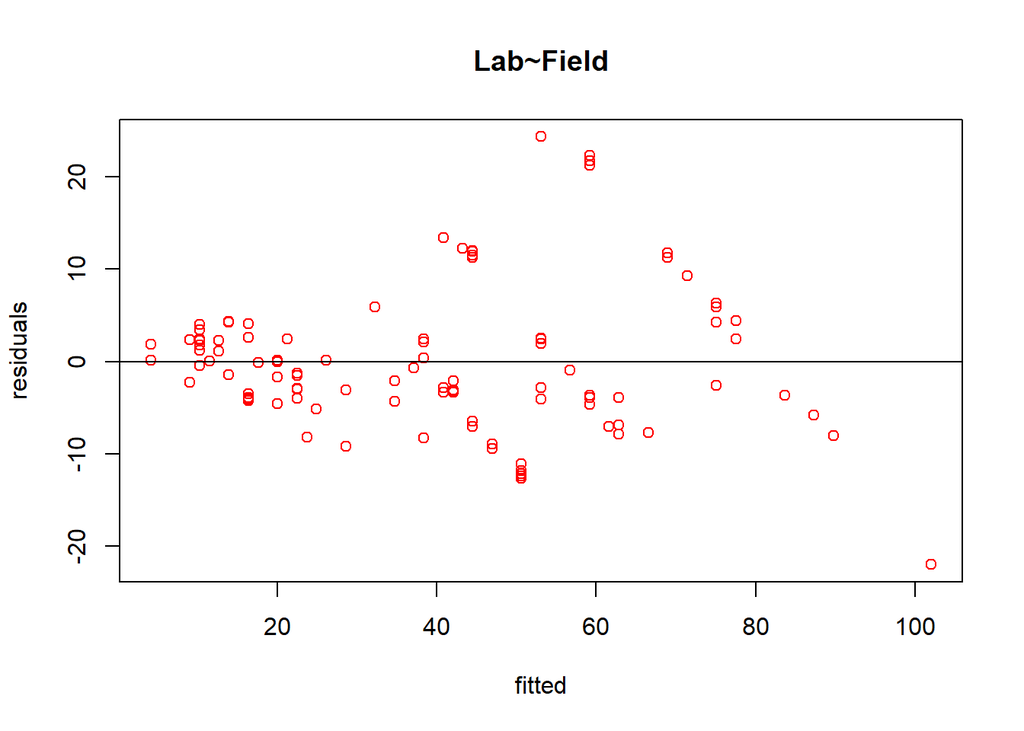

```r
plot(mod$fitted.values, mod$residuals,xlab = "fitted", ylab = "residuals" ,col = "Red", main = "Lab~Field")
abline(h=0)
```

From the plot we see that the constant variance assumption has been violated because of the clear mega phone shape.

#### (b)

```r
i <- order(pipeline$Field)
npipe <- pipeline[i,]
ff <- gl(12,9)[-108]
meanfield <- unlist(lapply(split(npipe$Field,ff),mean))
varlab <- unlist(lapply(split(npipe$Lab,ff),var))

#not removing the last obs from varlab and meanfield
modb<-lm(I(log(varlab))~I(log(meanfield)))
summary(modb)
```

```
##
## Call:
## lm(formula = I(log(varlab)) ~ I(log(meanfield)))
##
## Residuals:
##     Min      1Q  Median      3Q     Max
## -2.2038 -0.6729  0.1656  0.7205  1.1891
##
## Coefficients:
##                   Estimate Std. Error t value Pr(>|t|)
## (Intercept)        -0.3538     1.5715  -0.225   0.8264
## I(log(meanfield))   1.1244     0.4617   2.435   0.0351 *
## ---
## Signif. codes:  0 '***' 0.001 '**' 0.01 '*' 0.05 '.' 0.1 ' ' 1
##
## Residual standard error: 1.018 on 10 degrees of freedom
## Multiple R-squared:  0.3723, Adjusted R-squared:  0.3095
## F-statistic: 5.931 on 1 and 10 DF,  p-value: 0.03513
```

```r
#removing the last obs from both varlab and meanfield
modb<-lm(I(log(varlab[-length(varlab)]))~I(log(meanfield[-length(meanfield)])))
summary(modb)
```

```
##
## Call:
## lm(formula = I(log(varlab[-length(varlab)])) ~ I(log(meanfield[-length(meanfield)])))
##
## Residuals:
##      Min       1Q   Median       3Q      Max
## -1.00477 -0.42268  0.05989  0.37854  0.93815
##
## Coefficients:
##                                       Estimate Std. Error t value Pr(>|t|)
## (Intercept)                            -1.9352     1.0929  -1.771 0.110403
## I(log(meanfield[-length(meanfield)]))   1.6707     0.3296   5.070 0.000672
##
## (Intercept)
## I(log(meanfield[-length(meanfield)])) ***
## ---
## Signif. codes:  0 '***' 0.001 '**' 0.01 '*' 0.05 '.' 0.1 ' ' 1
##
## Residual standard error: 0.657 on 9 degrees of freedom
## Multiple R-squared:  0.7406, Adjusted R-squared:  0.7118
## F-statistic:  25.7 on 1 and 9 DF,  p-value: 0.0006723
```

After removing the last points as recommended by the book, the `a0` is -1.9351674 and `a1` is 1.6707234

#### (c)

```r
# applying log to both lab and field appears to correct the non cocnstant varaince voilation
modc<- lm(I(log(Lab))~I(log(Field)), data = pipeline)
summary(modc)
```

```
##
## Call:
## lm(formula = I(log(Lab)) ~ I(log(Field)), data = pipeline)
##
## Residuals:
##      Min       1Q   Median       3Q      Max
## -0.40212 -0.11853 -0.03092  0.13424  0.40209
##
## Coefficients:
##               Estimate Std. Error t value Pr(>|t|)
## (Intercept)   -0.06849    0.09305  -0.736    0.463
## I(log(Field))  1.05483    0.02743  38.457   <2e-16 ***
## ---
## Signif. codes:  0 '***' 0.001 '**' 0.01 '*' 0.05 '.' 0.1 ' ' 1
##
## Residual standard error: 0.1837 on 105 degrees of freedom
## Multiple R-squared:  0.9337, Adjusted R-squared:  0.9331
## F-statistic:  1479 on 1 and 105 DF,  p-value: < 2.2e-16
```

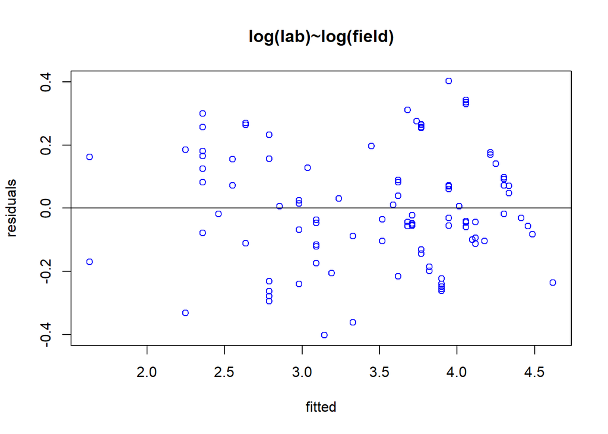

```r
#plot of the log(lab)~log(field)
plot(modc$fitted.values, modc$residuals,xlab = "fitted", ylab = "residuals" ,col = "blue", main="log(lab)~log(field)")
abline(h=0)
```

Applying log to both the predictor and response appears to correct the volition of constant variance.

### Question 8.3

```r
#head(salmonella)

mod_s<-lm(colonies~log(dose +1), data=salmonella)
summary(mod_s)
```

```
##
## Call:
## lm(formula = colonies ~ log(dose + 1), data = salmonella)
##
## Residuals:
##     Min      1Q  Median      3Q     Max
## -16.376  -6.882  -1.509   5.400  29.119
##
## Coefficients:
##               Estimate Std. Error t value Pr(>|t|)
## (Intercept)     19.823      5.064   3.915  0.00123 **
## log(dose + 1)    2.396      1.128   2.125  0.04955 *
## ---
## Signif. codes:  0 '***' 0.001 '**' 0.01 '*' 0.05 '.' 0.1 ' ' 1
##
## Residual standard error: 10.84 on 16 degrees of freedom
## Multiple R-squared:  0.2201, Adjusted R-squared:  0.1713
## F-statistic: 4.514 on 1 and 16 DF,  p-value: 0.04955
```

```r
mod_c<-lm(colonies~factor(log(dose +1)), data=salmonella)
summary(mod_c)
```

```
##
## Call:
## lm(formula = colonies ~ factor(log(dose + 1)), data = salmonella)
##
## Residuals:
##     Min      1Q  Median      3Q     Max
## -15.667  -3.917  -0.500   3.417  17.333
##
## Coefficients:
##                                       Estimate Std. Error t value Pr(>|t|)
## (Intercept)                             21.667      5.506   3.935  0.00198
## factor(log(dose + 1))2.39789527279837   -3.333      7.787  -0.428  0.67617
## factor(log(dose + 1))3.52636052461616    3.333      7.787   0.428  0.67617
## factor(log(dose + 1))4.61512051684126   21.000      7.787   2.697  0.01942
## factor(log(dose + 1))5.8111409929767    15.667      7.787   2.012  0.06722
## factor(log(dose + 1))6.90875477931522    8.000      7.787   1.027  0.32449
##
## (Intercept)                           **
## factor(log(dose + 1))2.39789527279837
## factor(log(dose + 1))3.52636052461616
## factor(log(dose + 1))4.61512051684126 *
## factor(log(dose + 1))5.8111409929767  .
## factor(log(dose + 1))6.90875477931522
## ---
## Signif. codes:  0 '***' 0.001 '**' 0.01 '*' 0.05 '.' 0.1 ' ' 1
##
## Residual standard error: 9.536 on 12 degrees of freedom
## Multiple R-squared:  0.5475, Adjusted R-squared:  0.359
## F-statistic: 2.904 on 5 and 12 DF,  p-value: 0.06047
```

```r
anova(mod_s, mod_c)
```

```
## Analysis of Variance Table
##
## Model 1: colonies ~ log(dose + 1)
## Model 2: colonies ~ factor(log(dose + 1))
##   Res.Df    RSS Df Sum of Sq      F Pr(>F)
## 1     16 1881.1
## 2     12 1091.3  4    789.73 2.1709 0.1342
```

Based on the `p-value` > .05 from the ANOVA test we fail to reject the null. As a result, a linear model is satisfactory.

### question 8.5

#### (a)

```r
#a
#least square method

ls<- lm(stack.loss~., data = stackloss)
summary(ls)
```

```
##
## Call:
## lm(formula = stack.loss ~ ., data = stackloss)
##
## Residuals:
##     Min      1Q  Median      3Q     Max
## -7.2377 -1.7117 -0.4551  2.3614  5.6978
##
## Coefficients:
##             Estimate Std. Error t value Pr(>|t|)
## (Intercept) -39.9197    11.8960  -3.356  0.00375 **
## Air.Flow      0.7156     0.1349   5.307  5.8e-05 ***
## Water.Temp    1.2953     0.3680   3.520  0.00263 **
## Acid.Conc.   -0.1521     0.1563  -0.973  0.34405
## ---
## Signif. codes:  0 '***' 0.001 '**' 0.01 '*' 0.05 '.' 0.1 ' ' 1
##
## Residual standard error: 3.243 on 17 degrees of freedom
## Multiple R-squared:  0.9136, Adjusted R-squared:  0.8983
## F-statistic:  59.9 on 3 and 17 DF,  p-value: 3.016e-09
```

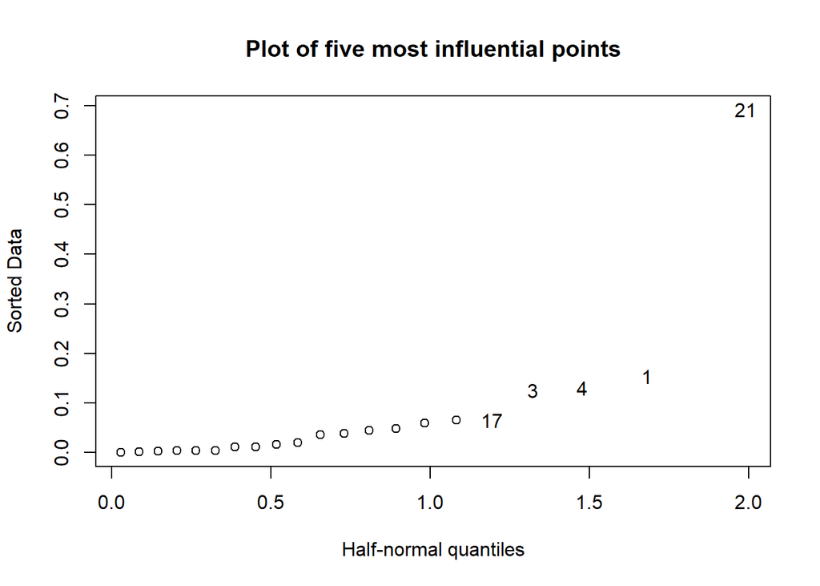

```r
#Checking for influential points, then looking at the 5 most influential points
halfnorm(cooks.distance(ls), 5, names(cooks.distance(ls)), main="Plot of five most influential points")
```

#### (b)

```r
#lad method

lad<- rq(stack.loss~., data = stackloss)
summary(lad)
```

```
##
## Call: rq(formula = stack.loss ~ ., data = stackloss)
##
## tau: [1] 0.5
##
## Coefficients:
##             coefficients lower bd  upper bd
## (Intercept) -39.68986    -41.61973 -29.67754
## Air.Flow      0.83188      0.51278   1.14117
## Water.Temp    0.57391      0.32182   1.41090
## Acid.Conc.   -0.06087     -0.21348  -0.02891
```

#### (c)

```r
#hubert method

hub<- rlm(stack.loss~., data = stackloss)
summary(hub)
```

```
##
## Call: rlm(formula = stack.loss ~ ., data = stackloss)
## Residuals:
##      Min       1Q   Median       3Q      Max
## -8.91753 -1.73127  0.06187  1.54306  6.50163
##
## Coefficients:
##             Value    Std. Error t value
## (Intercept) -41.0265   9.8073    -4.1832
## Air.Flow      0.8294   0.1112     7.4597
## Water.Temp    0.9261   0.3034     3.0524
## Acid.Conc.   -0.1278   0.1289    -0.9922
##
## Residual standard error: 2.441 on 17 degrees of freedom
```

#### (d)

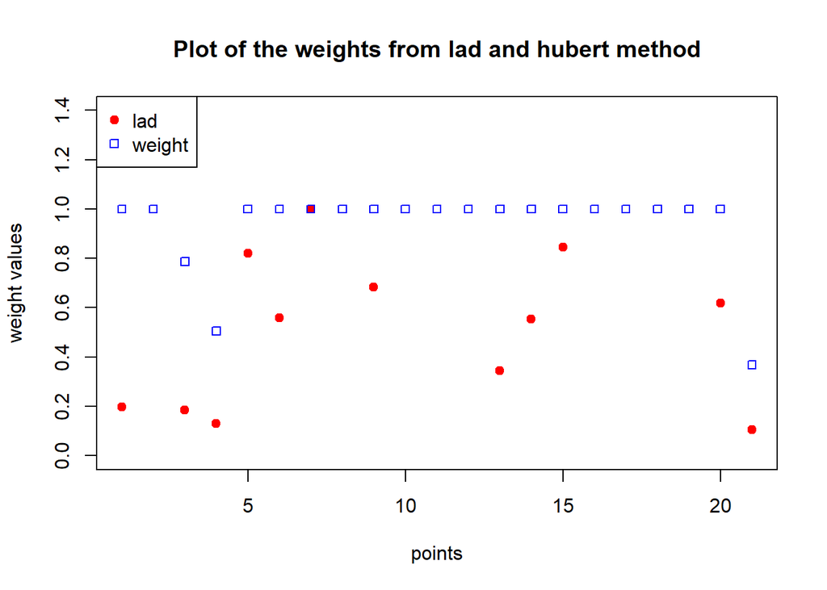

```r
#additional part added
# lad weights
w_lad<- 1/abs(lad$residuals)

#hubert weight
w_hub<- hub$w

#plot of the weights of lad and hubert method
plot(c(1:21), w_lad, ylim = c(0, 1.4), pch = 19, col = "red", xlab = "points", ylab = "weight values", main= "Plot of the weights from lad and hubert method")
lines(c(1:21), w_hub, col="blue", type ="o", lty = 0 , pch = 22)
nam<- c("red", "blue")
legend("topleft", legend = c("lad", "weight"),col=nam, pch=c(19,22))
```

From the halfnorm plot in part a, we see that the top 5 influential points are 21, 1,4,3, and 17. Now with the overlay plot of the weights of LAD and Hubert, we see the weight of most of these points are reduced in relation to the other points. With LAD, 1,3,4,and 21 weights are reduced. While with the Hubert 3,4, and 21 are assigned a lower weight. Overall these two methods prove that they are not as sensitive to the influence points as with least square and are therefore robust.

#### Comparison

Compare the results. Now use diagnostic methods to detect any outliers or influential points. Remove these points and then use least squares. Compare the results.

```r
#based on halfnorm point 21, 1 , 4, 3 and 17 appear to exert the top five influence on the model.
#removing these points

#
stackloss_n<- stackloss[c(-21,-1, -4, -3,-17),]

#

ls_n<- lm(stack.loss~., data = stackloss_n)
summary(ls_n)
```

```
##
## Call:
## lm(formula = stack.loss ~ ., data = stackloss_n)
##
## Residuals:
##     Min      1Q  Median      3Q     Max
## -2.5776 -0.7936  0.1845  0.7313  1.8323
##
## Coefficients:
##              Estimate Std. Error t value Pr(>|t|)
## (Intercept) -36.18166    6.22963  -5.808 8.37e-05 ***
## Air.Flow      0.79440    0.07030  11.301 9.41e-08 ***
## Water.Temp    0.58944    0.17460   3.376  0.00551 **
## Acid.Conc.   -0.08446    0.07836  -1.078  0.30226
## ---
## Signif. codes:  0 '***' 0.001 '**' 0.01 '*' 0.05 '.' 0.1 ' ' 1
##
## Residual standard error: 1.296 on 12 degrees of freedom
## Multiple R-squared:  0.9739, Adjusted R-squared:  0.9674
## F-statistic: 149.2 on 3 and 12 DF,  p-value: 9.202e-10
```

When I remove the top 5 influence points 21,1,4,3, and 17. Our new modified least square parameter coefficients resemble the LAD method . This is not a surprise because the lad method down weighted 4 of the 5 influence points detected by the halfnorm. However, with Hubert method, since 3 or the 5 points are down weighted our estimate coefficients were not a close match, but when I remove just the 3 points down weighted by Hubert our coefficients were every close. This also confirms that LAD and Hubert are not sensitive to influence points as the least square.

### question 9.3

```r
#question 9.3

#head(ozone)

mod9<- lm(O3~temp+humidity+ibh, data= ozone)

summary(mod9)
```

```
##
## Call:
## lm(formula = O3 ~ temp + humidity + ibh, data = ozone)
##
## Residuals:
##      Min       1Q   Median       3Q      Max
## -11.5291  -3.0137  -0.2249   2.8239  13.9303
##
## Coefficients:
##               Estimate Std. Error t value Pr(>|t|)
## (Intercept) -1.049e+01  1.616e+00  -6.492 3.16e-10 ***
## temp         3.296e-01  2.109e-02  15.626  < 2e-16 ***
## humidity     7.738e-02  1.339e-02   5.777 1.77e-08 ***
## ibh         -1.004e-03  1.639e-04  -6.130 2.54e-09 ***
## ---
## Signif. codes:  0 '***' 0.001 '**' 0.01 '*' 0.05 '.' 0.1 ' ' 1
##
## Residual standard error: 4.524 on 326 degrees of freedom
## Multiple R-squared:  0.684,  Adjusted R-squared:  0.6811
## F-statistic: 235.2 on 3 and 326 DF,  p-value: < 2.2e-16
```

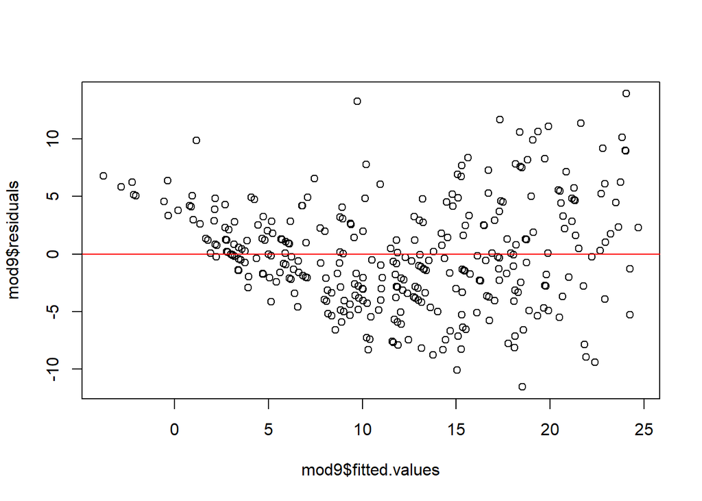

```r
plot(mod9$fitted.values, mod9$residuals)
abline(h=0, col= "red")
```

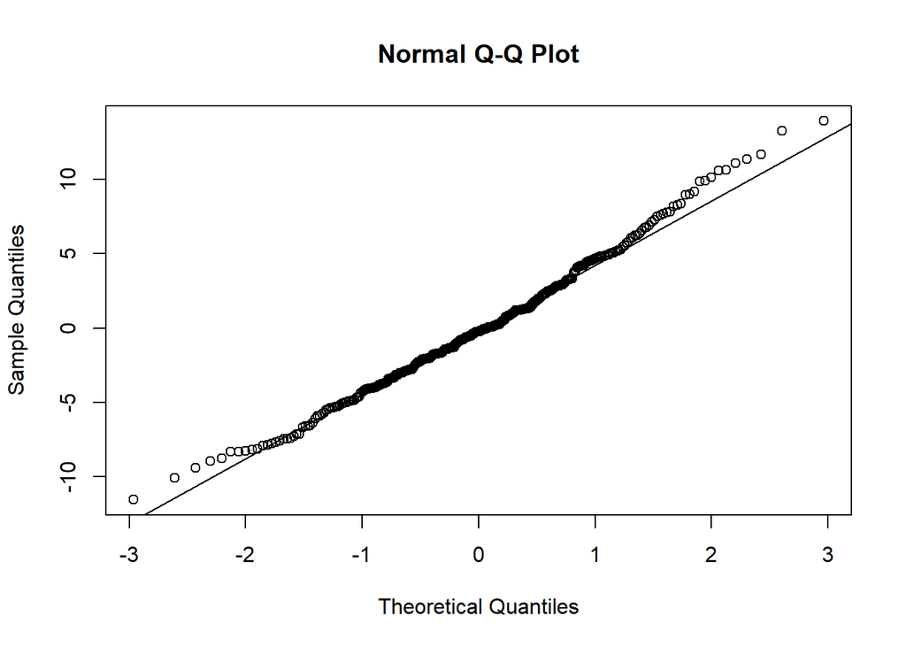

```r
#the constant variance assumption appears violated


qqnorm(mod9$residuals)
qqline(mod9$residuals)
```

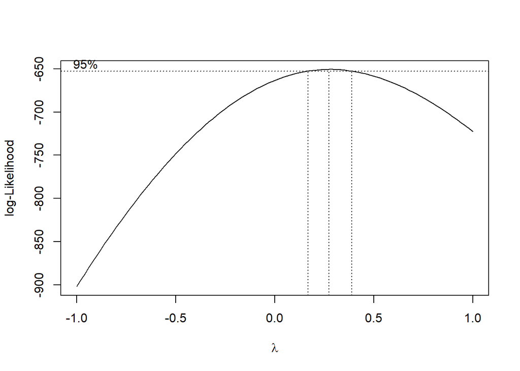

```r
boxcox(mod9, plotit = T, lambda=seq(-1,1, by = .1))
```

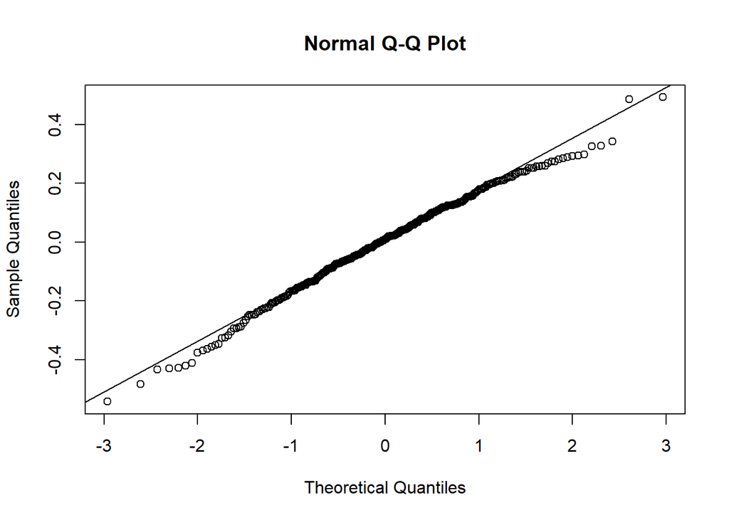

```r
#using lambda of of .25 from box cox in response transformation
mod9_<- lm(I(O3**.25)~temp+humidity+ibh, data= ozone)


qqnorm(mod9_$residuals)
qqline(as.data.frame(mod9_$residuals))
```

Using the value of .25 from the box cox, we apply this value to the response and based on the new qqplot the problem of long tail appears corrected.

### question 9.8

#### (a)

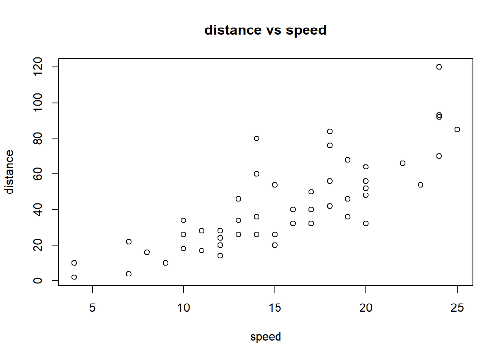

```r
#a
plot(cars$speed, cars$dist, xlab = "speed", ylab = "distance", main = "distance vs speed")
```

#### (b)

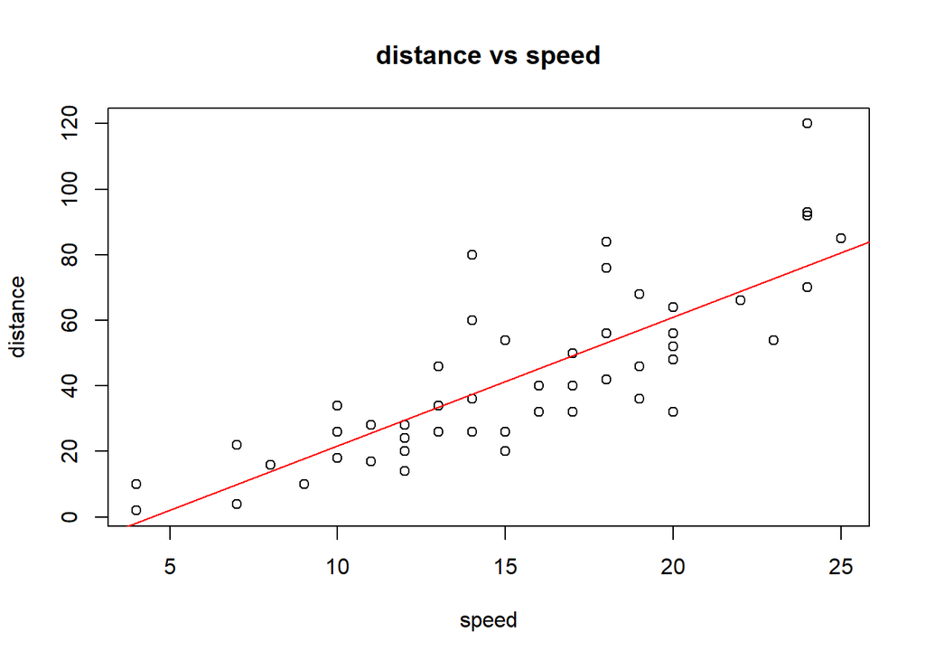

```r
#b
plot(cars$speed, cars$dist, xlab = "speed", ylab = "distance", main = "distance vs speed")
mod8<- lm(dist~speed, data = cars)
abline(mod8, col = "red")
```

```r
summary(mod8)
```

```
##
## Call:
## lm(formula = dist ~ speed, data = cars)
##
## Residuals:
##     Min      1Q  Median      3Q     Max
## -29.069  -9.525  -2.272   9.215  43.201
##
## Coefficients:
##             Estimate Std. Error t value Pr(>|t|)
## (Intercept) -17.5791     6.7584  -2.601   0.0123 *
## speed         3.9324     0.4155   9.464 1.49e-12 ***
## ---
## Signif. codes:  0 '***' 0.001 '**' 0.01 '*' 0.05 '.' 0.1 ' ' 1
##
## Residual standard error: 15.38 on 48 degrees of freedom
## Multiple R-squared:  0.6511, Adjusted R-squared:  0.6438
## F-statistic: 89.57 on 1 and 48 DF,  p-value: 1.49e-12
```

#### (c)

```r
#c
plot(cars$speed, cars$dist, xlab = "speed", ylab = "distance", main = "distance vs speed")

mod8q<- lm(dist~poly(speed, 2), data = cars)
summary(mod8q)
```

```
##
## Call:
## lm(formula = dist ~ poly(speed, 2), data = cars)
##
## Residuals:
##     Min      1Q  Median      3Q     Max
## -28.720  -9.184  -3.188   4.628  45.152
##
## Coefficients:
##                 Estimate Std. Error t value Pr(>|t|)
## (Intercept)       42.980      2.146  20.026  < 2e-16 ***
## poly(speed, 2)1  145.552     15.176   9.591 1.21e-12 ***
## poly(speed, 2)2   22.996     15.176   1.515    0.136
## ---
## Signif. codes:  0 '***' 0.001 '**' 0.01 '*' 0.05 '.' 0.1 ' ' 1
##
## Residual standard error: 15.18 on 47 degrees of freedom
## Multiple R-squared:  0.6673, Adjusted R-squared:  0.6532
## F-statistic: 47.14 on 2 and 47 DF,  p-value: 5.852e-12
```

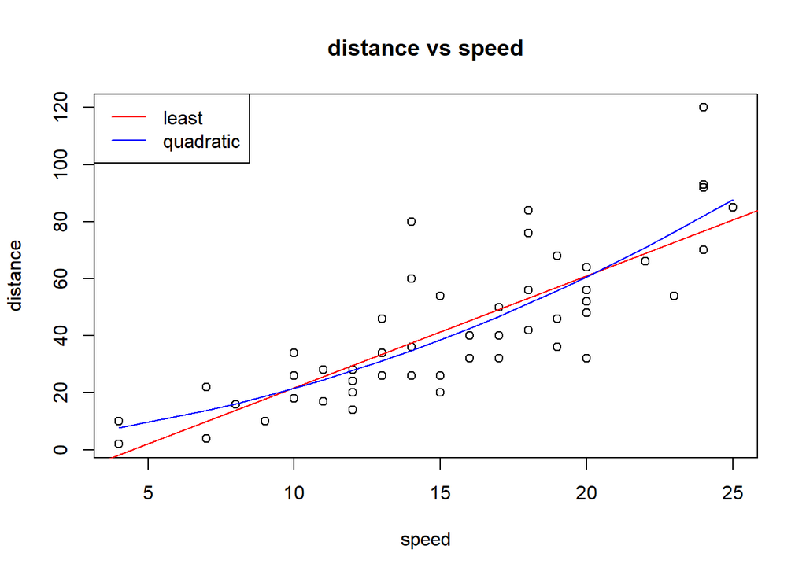

```r
abline(mod8, col = "red")
lines(cars$speed, mod8q$fitted.values, col= "blue")
legend("topleft", legend = c("least", "quadratic"),col=c("red", "blue"), lty=c(1,1))
```

#### (d)

```r
#d
plot(cars$speed, cars$dist, xlab = "speed", ylab = "distance", main = "distance vs speed")
mod8s<- lm(I(sqrt(dist))~speed, data = cars)
summary(mod8s)
```

```
##
## Call:
## lm(formula = I(sqrt(dist)) ~ speed, data = cars)
##
## Residuals:
##     Min      1Q  Median      3Q     Max
## -2.0684 -0.6983 -0.1799  0.5909  3.1534
##
## Coefficients:
##             Estimate Std. Error t value Pr(>|t|)
## (Intercept)  1.27705    0.48444   2.636   0.0113 *
## speed        0.32241    0.02978  10.825 1.77e-14 ***
## ---
## Signif. codes:  0 '***' 0.001 '**' 0.01 '*' 0.05 '.' 0.1 ' ' 1
##
## Residual standard error: 1.102 on 48 degrees of freedom
## Multiple R-squared:  0.7094, Adjusted R-squared:  0.7034
## F-statistic: 117.2 on 1 and 48 DF,  p-value: 1.773e-14
```

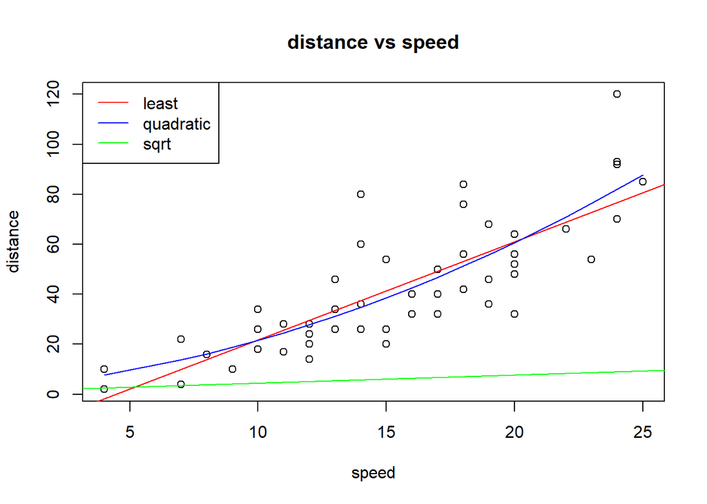

```r
abline(mod8, col = "red")
lines(cars$speed, mod8q$fitted.values, col= "blue")
abline(mod8s, col = "green")
legend("topleft", legend = c("least", "quadratic", "sqrt"),col=c("red", "blue", "green"), lty=c(1,1, 1))
```

#### (e)

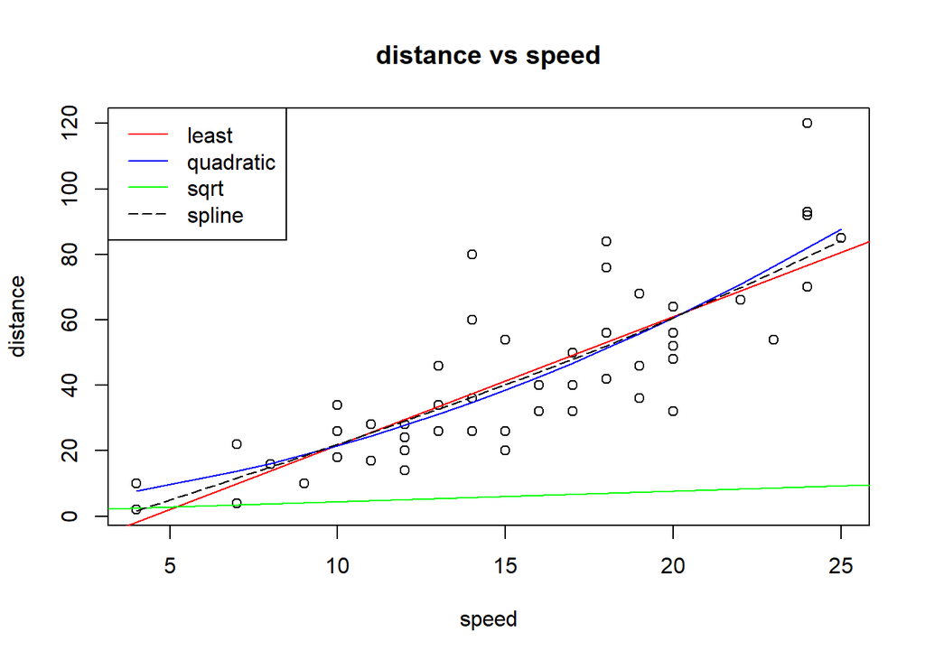

```r
#e

plot(cars$speed, cars$dist, xlab = "speed", ylab = "distance", main = "distance vs speed")
abline(mod8, col = "red")
lines(cars$speed, mod8q$fitted.values, col= "blue")
abline(mod8s, col = "green")
lines(smooth.spline(cars$speed, cars$dist), col = "black" , lty = 5)
legend("topleft", legend = c("least", "quadratic", "sqrt", "spline"),col=c("red", "blue", "green", "black"), lty=c(1,1, 1, 5))
```